# Targeting A Housing Subsidy

Shengao Yi

October 29, 2022

## 1. Introduction

The Department of Housing and Community Development (HCD) has launched a tax credit program for nearly twenty years. HCD tries their best to proactively reach out to eligible homeowners ever year, but the uptake of the credit is woefully inadequate. HCD thinks the low conversion rate is due to the fact that the agency reaches out to eligible homeowners at random. The cost of marketing material allocation is $2,850 per year and the credit cost is $5,000. According to the researchers in Philadelphia, houses that transacted after taking the credit, sold with a $10,000 premium, on average. Also homes surrounding the repaired home see an aggregate premium of $56,000, on average. So the target of this project is to train a best classifier and use the results to inform a cost/benefit analysis.

```r
# Rmarkdown global setting
knitr::opts_chunk$set(echo = TRUE)
knitr::opts_chunk$set(message = FALSE)
knitr::opts_chunk$set(warning = FALSE)
knitr::opts_chunk$set(cache = TRUE)
knitr::opts_chunk$set(fig.align = 'center')

#----------------------------------------------------------------------------------------------------------

# Import libraries
library(tidyverse)
library(tidycensus)
library(sf)
library(spdep)
library(caret)
library(ckanr)
library(FNN)
library(grid)
library(gridExtra)
library(ggcorrplot)# plot correlation plot
library(corrplot)
library(corrr)      # another way to plot correlation plot
library(kableExtra)
library(jtools)     # for regression model plots
library(ggstance) # to support jtools plots
library(ggpubr)    # plotting R^2 value on ggplot point scatter
library(broom.mixed) # needed for effects plots
library(knitr)
library(rmarkdown)
library(RSocrata)
library(viridis)
library(ggplot2)
library(stargazer)
library(XML)
library(data.table)
library(ggpmisc)
library(patchwork)
library(spatstat)
library(raster)
library(classInt)   # for KDE and ML risk class intervals
library(tableHTML)
library(tidyverse)
library(caret)
library(knitr)
library(pscl)
library(plotROC)
library(pROC)
library(scales)


# Temp
source("https://raw.githubusercontent.com/urbanSpatial/Public-Policy-Analytics-Landing/master/functions.r")
root.dir = "https://raw.githubusercontent.com/urbanSpatial/Public-Policy-Analytics-Landing/master/DATA/"

# Etc
options(scipen=999)
options(tigris_class = "sf")

# functions

st_c    <- st_coordinates
st_coid <- st_centroid


# Colors ("https://coolors.co/gradient-palette/a8f368-f9035e?number=7")
bluePalette5 <- c("#eff3ff","#bdd7e7","#6baed6","#3182bd","#08519c")
blue2Palette5 <- c("#08519c","#3182bd","#6baed6","#bdd7e7","#eff3ff")
H_bluePalette5 <- c("#eff3ff","#bdd7e7","#6baed6","#3182bd","#252525")
orangePalette5 <- c("#FFF2E8","#FFD6B6","#FEB984","#FE9D51","#FD801F")
orange2Palette5 <- c("#FFDFD0","#FFB89F","#FF926E","#FF6B3D","#FF440C")
greyPalette5 <- c("#f7f7f7","#cccccc","#969696","#636363","#252525")
greenPalette5 <- c("#edf8e9","#bae4b3","#74c476","#31a354","#006d2c")
purplePalette5 <- c("#f2f0f7","#cbc9e2","#9e9ac8","#756bb1","#54278f")
palette5 <- c("#981FAC","#CB0F8B","#FF006A","#FE4C35","#FE9900")
palette2 <- c("#981FAC","#FF006A")

# Load Data

housingSubsidy <- read.csv("https://github.com/urbanSpatial/Public-Policy-Analytics-Landing/raw/master/DATA/Chapter6/housingSubsidy.csv")

housingSubsidy <-
  housingSubsidy %>%
  na.omit()
```

## 2. Data Visualization

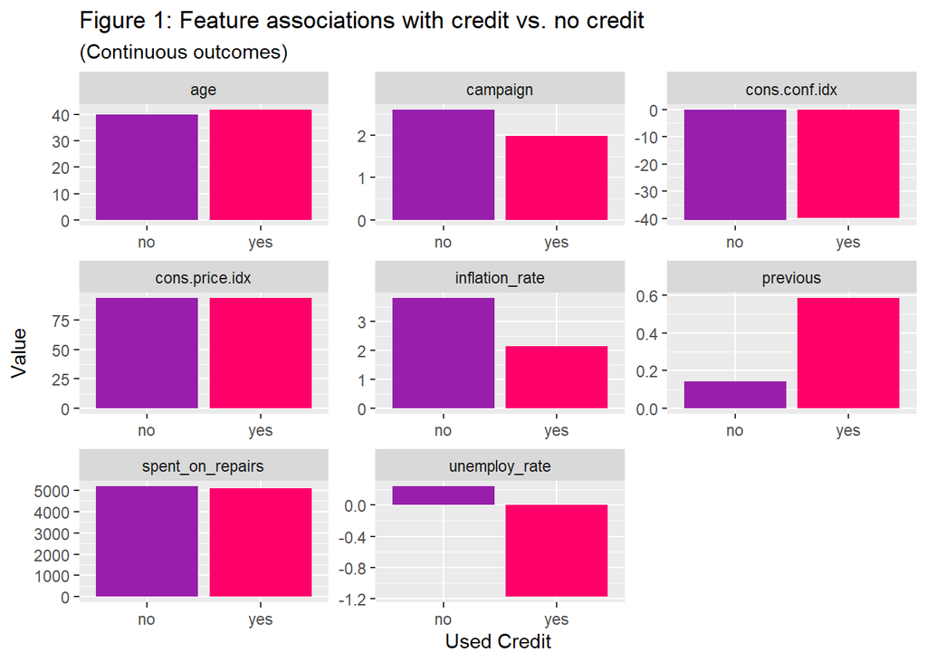

```r
housingSubsidy %>%
  dplyr::select(age, previous, unemploy_rate, cons.price.idx, cons.conf.idx, inflation_rate, spent_on_repairs, campaign, y) %>%
  gather(Variable, value, -y) %>%
    ggplot(aes(y, value, fill=y)) +
      geom_bar(position = "dodge", stat = "summary", fun = "mean") +
      facet_wrap(~Variable, scales = "free") +
      scale_fill_manual(values = palette2) +
      labs(x="Used Credit", y="Value",
           title = "Figure 1: Feature associations with credit vs. no credit",
           subtitle = "(Continuous outcomes)") +
      theme(legend.position = "none")
```

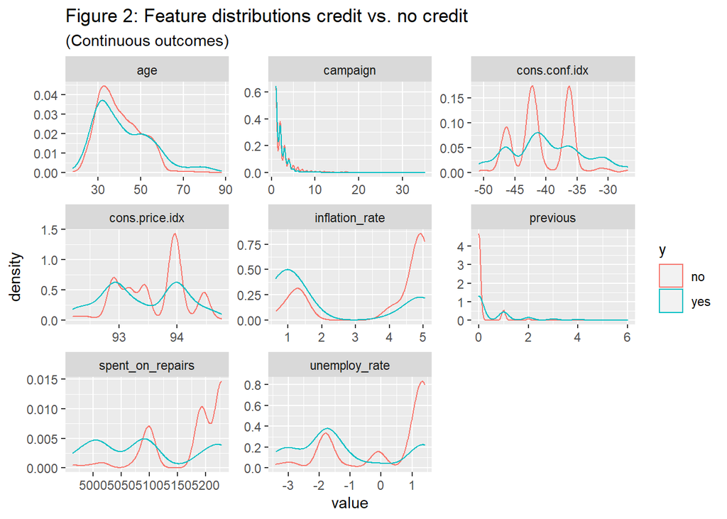

```r
housingSubsidy %>%
  dplyr::select(age, previous, unemploy_rate, cons.price.idx, cons.conf.idx, inflation_rate, spent_on_repairs, campaign, y) %>%
  gather(Variable, value, -y) %>%
  ggplot() +
  geom_density(aes(value, color=y), fill = "transparent") +
  facet_wrap(~Variable, scales = "free") +
  scale_fill_manual(values = palette2) +
  labs(title = "Figure 2: Feature distributions credit vs. no credit",
       subtitle = "(Continuous outcomes)")
```

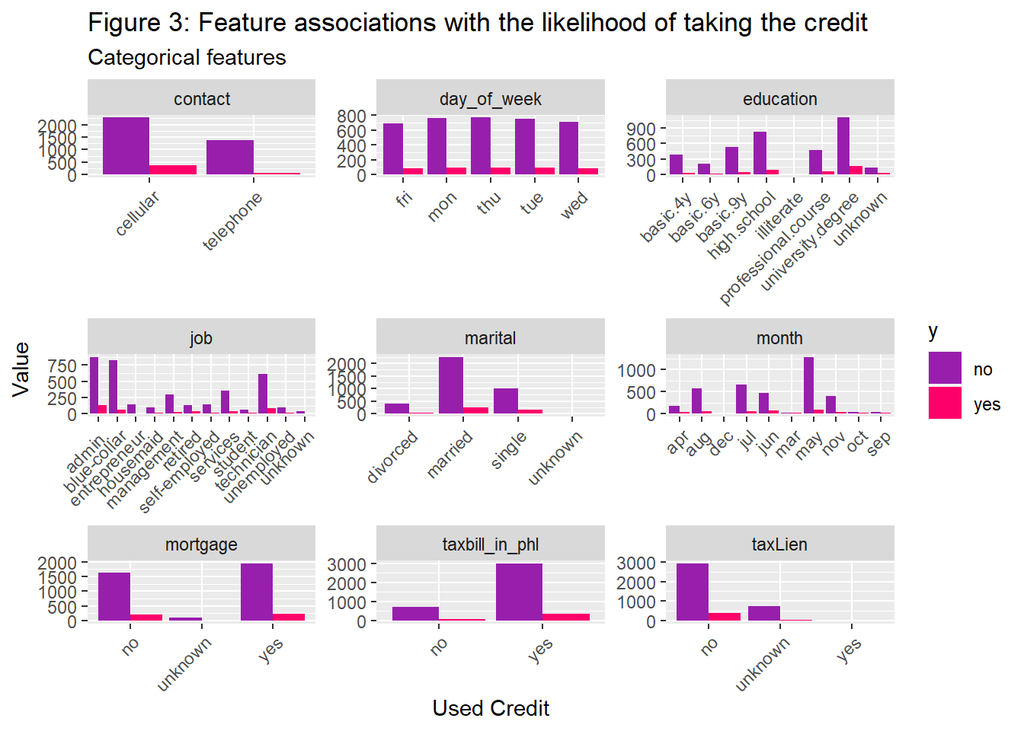

```r
housingSubsidy %>%
  dplyr::select(y, mortgage, taxbill_in_phl, taxLien, job, marital, education, contact, month, day_of_week) %>%
  gather(Variable, value, -y) %>%
  count(Variable, value, y) %>%
    ggplot(., aes(value, n, fill = y)) +
      geom_bar(position = "dodge", stat="identity") +
      facet_wrap(~Variable, scales="free") +
      scale_fill_manual(values = palette2) +
      labs(x="Used Credit", y="Value",
           title = "Figure 3: Feature associations with the likelihood of taking the credit",
           subtitle = "Categorical features") +
      theme(axis.text.x = element_text(angle = 45, hjust = 1))
```

## 3. Model Building & Cost-Benefit Analysis

### 3.1 Reclassify the Category Data

Due to a large number of types in some categorical features, we can reclassify them and create new dataset.

**Season**: We can categorize the months into four season: Winter, Spring, Summer and Fall.

**Education Level**: We can categorize the education level into four categories: Elementary School, High School, Higher Education and Illiterate.

**Contact**: We can categorize the number of days into weeks.

**Employment**: We can categorize the employment status into unemploy, retired and employ.

```r
# Season
housingSubsidy <-
  housingSubsidy %>%
  mutate(Season = case_when(
    month == "dec" | month == "jan" | month == "feb" ~ "Winter",
    month == "mar" | month == "apr" | month == "may" ~ "Spring",
    month == "jun" | month == "jul" | month == "aug" ~ "Summer",
    month == "sep" | month == "oct" | month == "nov" ~ "Fall"))

# Previous Contact
housingSubsidy <-
  housingSubsidy %>%
  mutate(Contact = case_when(
    pdays == 999 ~ "No Contact",
    pdays < 7 ~ "1 week",
    pdays >= 7 & pdays < 14 ~ "2 Weeks",
    pdays >= 15 & pdays < 21 ~ "3 Weeks",
    pdays >= 22 ~ "More than 3 Weeks"))

# Education Classification
housingSubsidy <-
  housingSubsidy %>%
  mutate(Education = case_when(
    education == "basic.9y" |education == "basic.6y" | education == "basic.4y" ~ "Elementary School",
    education == "high.school"  ~ "High School",
    education == "university.degree" |education == "professional.course"  ~ "Higher Education",
    education == "unknown" |education == "illiterate"  ~ "Illiterate"))

# Employment Status
housingSubsidy <-
  housingSubsidy %>%
  mutate(EmploymentStatus = case_when(
    job == "student" | job == "unemployed" ~ "unemployed",
    job == "retired" ~ "retired",
    TRUE  ~ "employed"))
```

### 3.2 Training/Testing sets

Then, we created the training and test sets. CreateDataPartition is used to split the data. A 65% sample is used here to reduce processing time.

```r
set.seed(3456)
trainIndex <- createDataPartition(housingSubsidy$X, p = .65,
                                  list = FALSE,
                                  times = 1)
housingSubsidyTrain <- housingSubsidy[ trainIndex,]
housingSubsidyTest  <- housingSubsidy[-trainIndex,]
```

### 3.3 Model Evaluation

In this section, we have run two different regression models, kitchen sink and feature engineered model. The kitchen sink model contains all the original data while excluding the engineered features. The feature engineered model includes the new reclassified features except for the original data.

For the kitchen sink model, we get a McFadden score of 0.224, AIC is 1548.6. For the feature engineered model, the McFadden score is 0.201, AIC is 1557.4. The McFadden score is a metric of goodness for fit, which is demonstrated - the higher, the better. So the kitchen sink is better fit than the engineered model. To improve the McFadden score of engineered model, we have made a lot of trials, but the kitchen sink model is still better. Considering that there is no significant difference between the two models, we use the engineered model for further study.

```r
# Kitchen sink
housingSubsidy_kitchensink <- glm(y_numeric ~ .,
                  data = housingSubsidyTrain %>%
                    dplyr::select(-Education, -Season, -Contact, -EmploymentStatus, -X, -y),
                  family="binomial" (link="logit"))

summary(housingSubsidy_kitchensink)
```

```
##
## Call:
## glm(formula = y_numeric ~ ., family = binomial(link = "logit"),
##     data = housingSubsidyTrain %>% dplyr::select(-Education,
##         -Season, -Contact, -EmploymentStatus, -X, -y))
##
## Deviance Residuals:
##     Min       1Q   Median       3Q      Max
## -1.9118  -0.3973  -0.3236  -0.2501   2.9558
##
## Coefficients:
##                                 Estimate  Std. Error z value Pr(>|z|)
## (Intercept)                  -14.7194037 132.6962970  -0.111  0.91168
## age                            0.0181358   0.0084208   2.154  0.03126 *
## jobblue-collar                -0.1370818   0.2790972  -0.491  0.62331
## jobentrepreneur               -1.0075538   0.6318085  -1.595  0.11078
## jobhousemaid                   0.0374946   0.4683711   0.080  0.93619
## jobmanagement                 -0.6772189   0.3220094  -2.103  0.03546 *
## jobretired                    -0.0892092   0.3671645  -0.243  0.80803
## jobself-employed              -0.1223999   0.3720332  -0.329  0.74215
## jobservices                   -0.0295000   0.2932156  -0.101  0.91986
## jobstudent                     0.0292545   0.4443249   0.066  0.94750
## jobtechnician                 -0.0115265   0.2368518  -0.049  0.96119
## jobunemployed                  0.1756488   0.4299164   0.409  0.68286
## jobunknown                    -1.9158314   1.1583245  -1.654  0.09813 .
## maritalmarried                 0.0509522   0.2467459   0.206  0.83640
## maritalsingle                  0.2444540   0.2817425   0.868  0.38559
## maritalunknown                 0.9619534   1.1757847   0.818  0.41328
## educationbasic.6y              0.3862787   0.4318152   0.895  0.37103
## educationbasic.9y              0.3766271   0.3389878   1.111  0.26655
## educationhigh.school           0.2751538   0.3281430   0.839  0.40174
## educationilliterate          -11.9672263 535.4114678  -0.022  0.98217
## educationprofessional.course   0.3737024   0.3555392   1.051  0.29322
## educationuniversity.degree     0.3672344   0.3285539   1.118  0.26368
## educationunknown               0.1553014   0.4422942   0.351  0.72549
## taxLienunknown                 0.1839176   0.2121394   0.867  0.38596
## taxLienyes                   -10.3843194 535.4114679  -0.019  0.98453
## mortgageunknown               -0.6170969   0.5429929  -1.136  0.25576
## mortgageyes                   -0.2542545   0.1457380  -1.745  0.08105 .
## taxbill_in_phlyes             -0.0884240   0.1868325  -0.473  0.63601
```

[output cut: 19 more lines]

```
## unemploy_rate                 -0.3832123   0.5002253  -0.766  0.44363
## cons.price.idx                 0.5296563   0.8787145   0.603  0.54667
## cons.conf.idx                  0.0635503   0.0293593   2.165  0.03042 *
## inflation_rate                 0.1883859   0.4544335   0.415  0.67847
## spent_on_repairs              -0.0067702   0.0107016  -0.633  0.52697
## ---
## Signif. codes:  0 '***' 0.001 '**' 0.01 '*' 0.05 '.' 0.1 ' ' 1
##
## (Dispersion parameter for binomial family taken to be 1)
##
##     Null deviance: 1862.1  on 2678  degrees of freedom
## Residual deviance: 1444.6  on 2627  degrees of freedom
## AIC: 1548.6
##
## Number of Fisher Scoring iterations: 12
```

```r
pR2(housingSubsidy_kitchensink) #McFadden: 0.224
```

```
## fitting null model for pseudo-r2
```

```
##          llh      llhNull           G2     McFadden         r2ML         r2CU
## -722.2770968 -931.0501911  417.5461887    0.2242340    0.1443201    0.2880860
```

```r
# Engineering
housingSubsidy_engineered <- glm(y_numeric ~ .,
                  data=housingSubsidyTrain %>% dplyr::select(-month, -education, -pdays, -job, -X, -y, cons.price.idx, -cons.conf.idx),
                  family="binomial" (link="logit"))

summary(housingSubsidy_engineered)
```

```
##
## Call:
## glm(formula = y_numeric ~ ., family = binomial(link = "logit"),
##     data = housingSubsidyTrain %>% dplyr::select(-month, -education,
##         -pdays, -job, -X, -y, cons.price.idx, -cons.conf.idx))
##
## Deviance Residuals:
##     Min       1Q   Median       3Q      Max
## -2.1146  -0.4069  -0.3266  -0.2685   2.8299
##
## Coefficients:
##                              Estimate Std. Error z value Pr(>|z|)
## (Intercept)                 41.437635  46.538050   0.890 0.373249
## age                          0.017490   0.007902   2.213 0.026864 *
## maritalmarried               0.049884   0.240522   0.207 0.835698
## maritalsingle                0.318146   0.272314   1.168 0.242684
## maritalunknown               1.038659   1.147564   0.905 0.365413
## taxLienunknown               0.133471   0.208219   0.641 0.521515
## taxLienyes                  -9.262147 324.744023  -0.029 0.977246
## mortgageunknown             -0.311315   0.508733  -0.612 0.540576
## mortgageyes                 -0.182542   0.142649  -1.280 0.200665
## taxbill_in_phlyes           -0.052516   0.184350  -0.285 0.775744
## contacttelephone            -0.878079   0.249571  -3.518 0.000434 ***
## day_of_weekmon               0.041288   0.219424   0.188 0.850748
## day_of_weekthu              -0.049010   0.228065  -0.215 0.829849
## day_of_weektue               0.065036   0.224207   0.290 0.771762
## day_of_weekwed              -0.028229   0.232182  -0.122 0.903231
## campaign                    -0.060228   0.041771  -1.442 0.149340
## previous                     0.172633   0.210475   0.820 0.412097
## poutcomenonexistent          0.692472   0.338140   2.048 0.040571 *
## poutcomesuccess              0.602377   0.843807   0.714 0.475301
## unemploy_rate               -0.686171   0.261578  -2.623 0.008711 **
## cons.price.idx               0.346781   0.313771   1.105 0.269071
## inflation_rate               0.791604   0.301828   2.623 0.008724 **
## spent_on_repairs            -0.015424   0.004536  -3.400 0.000673 ***
## SeasonSpring                 0.697708   0.303854   2.296 0.021665 *
## SeasonSummer                 0.873261   0.259855   3.361 0.000778 ***
## SeasonWinter                 0.933731   0.651620   1.433 0.151875
## Contact2 Weeks               0.613602   0.685277   0.895 0.370569
## Contact3 Weeks              -1.324662   1.089505  -1.216 0.224046
## ContactNo Contact           -1.249411   0.891439  -1.402 0.161044
## EducationHigh School         0.110882   0.207086   0.535 0.592345
## EducationHigher Education    0.181084   0.181469   0.998 0.318338
## EducationIlliterate          0.026985   0.358706   0.075 0.940033
## EmploymentStatusretired      0.084320   0.326630   0.258 0.796291
## EmploymentStatusunemployed   0.206654   0.296164   0.698 0.485323
## ---
## Signif. codes:  0 '***' 0.001 '**' 0.01 '*' 0.05 '.' 0.1 ' ' 1
##
## (Dispersion parameter for binomial family taken to be 1)
##
##     Null deviance: 1861.9  on 2677  degrees of freedom
## Residual deviance: 1489.4  on 2644  degrees of freedom
##   (因为不存在，1个观察量被删除了)
## AIC: 1557.4
##
## Number of Fisher Scoring iterations: 11
```

```r
pR2(housingSubsidy_engineered) #McFadden: 0.201
```

```
## fitting null model for pseudo-r2
```

```
##          llh      llhNull           G2     McFadden         r2ML         r2CU
## -744.7197631 -930.9330845  372.4266428    0.2000287    0.1298320    0.2591209
```

### 3.4 Cross validation

```r
ctrl <- trainControl(method = "cv", number = 100, classProbs=TRUE, summaryFunction=twoClassSummary)

cvFit_kitchensink <- train(y ~ .,
                  data = housingSubsidy %>%
                    dplyr::select(-Education, -Season, -Contact, -EmploymentStatus, -X, -y_numeric),
                method="glm", family="binomial",
                metric="ROC", trControl = ctrl)

cvFit_engineered <- train(y ~ .,
                  data = housingSubsidy %>%
                    na.omit() %>%
                    dplyr::select(-month, -education, -pdays, -job, -y_numeric, -X),
                method="glm", family="binomial",
                metric="ROC", trControl = ctrl)

cvFit_kitchensink
```

```
## Generalized Linear Model
##
## 4119 samples
##   19 predictor
##    2 classes: 'no', 'yes'
##
## No pre-processing
## Resampling: Cross-Validated (100 fold)
## Summary of sample sizes: 4078, 4077, 4078, 4079, 4079, 4079, ...
## Resampling results:
##
##   ROC        Sens       Spec
##   0.7645034  0.9801652  0.2155
```

```r
cvFit_engineered
```

```
## Generalized Linear Model
##
## 4117 samples
##   19 predictor
##    2 classes: 'no', 'yes'
##
## No pre-processing
## Resampling: Cross-Validated (100 fold)
## Summary of sample sizes: 4076, 4075, 4076, 4075, 4075, 4076, ...
## Resampling results:
##
##   ROC        Sens       Spec
##   0.7664839  0.9839414  0.222
```

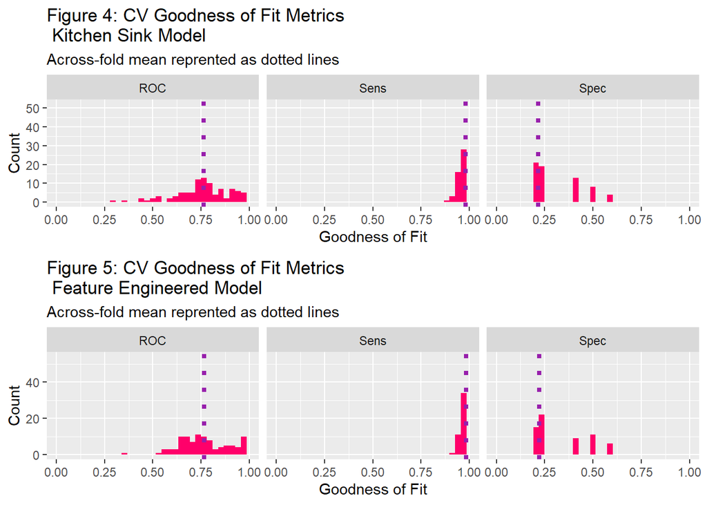

```r
grid.arrange(ncol = 1,
  dplyr::select(cvFit_kitchensink$resample, -Resample) %>%
  gather(metric, value) %>%
  left_join(gather(cvFit_kitchensink$results[2:4], metric, mean)) %>%
  ggplot(aes(value)) +
  geom_histogram(bins=35, fill = "#FF006A") +
  facet_wrap(~metric) +
  geom_vline(aes(xintercept = mean), colour = "#981FAC", linetype = 3, size = 1.5) +
  scale_x_continuous(limits = c(0, 1)) +
  labs(x="Goodness of Fit", y="Count", title="Figure 4: CV Goodness of Fit Metrics \n Kitchen Sink Model",
       subtitle = "Across-fold mean reprented as dotted lines"),
  dplyr::select(cvFit_engineered$resample, -Resample) %>%
  gather(metric, value) %>%
  left_join(gather(cvFit_engineered$results[2:4], metric, mean)) %>%
  ggplot(aes(value)) +
  geom_histogram(bins=35, fill = "#FF006A") +
  facet_wrap(~metric) +
  geom_vline(aes(xintercept = mean), colour = "#981FAC", linetype = 3, size = 1.5) +
  scale_x_continuous(limits = c(0, 1)) +
  labs(x="Goodness of Fit", y="Count", title="Figure 5: CV Goodness of Fit Metrics \n Feature Engineered Model",
       subtitle = "Across-fold mean reprented as dotted lines"))
```

### 3.5 Predictions

After obtaining the models, we can make predictions of taking the tax credit. A negative value or 0 means they did not take the tax credit. In general, a good model will have a peak near 0 for the negatives (no tax credit), and a peak close to 1 for the positives (take tax credit). In Figure 6, we can find that our model is better at predicting the negatives rather than the positives.

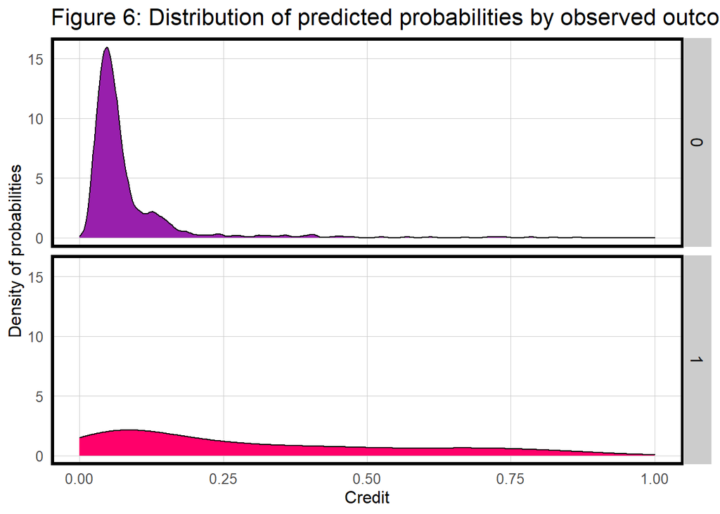

```r
testProbs <- data.frame(Outcome = as.factor(housingSubsidyTest$y_numeric),
                        Probs = predict(housingSubsidy_engineered, housingSubsidyTest, type= "response"))

ggplot(testProbs, aes(x = Probs, fill = as.factor(Outcome))) +
  geom_density() +
  facet_grid(Outcome ~ .) +
  scale_fill_manual(values = palette2) + xlim(0, 1) +
  labs(x = "Credit", y = "Density of probabilities",
       title = "Figure 6: Distribution of predicted probabilities by observed outcome") +
  plotTheme() + theme(strip.text.x = element_text(size = 18),
        legend.position = "none")
```

### 3.6 Confusion Matrix

The confusion matrix for the threshold of 50% shows us the rate at which we got True Positives (Sensitivity), False Positives, True Negatives (Specificity) and False Negatives for that threshold.

```r
testProbs <-
  testProbs %>%
  mutate(predOutcome  = as.factor(ifelse(testProbs$Probs > 0.5 , 1, 0)))

caret::confusionMatrix(testProbs$predOutcome, testProbs$Outcome,
                       positive = "1")
```

```
## Confusion Matrix and Statistics
##
##           Reference
## Prediction    0    1
##          0 1269  118
##          1   16   36
##
##                Accuracy : 0.9069
##                  95% CI : (0.8907, 0.9214)
##     No Information Rate : 0.893
##     P-Value [Acc > NIR] : 0.04608
##
##                   Kappa : 0.3124
##
##  Mcnemar's Test P-Value : < 0.0000000000000002
##
##             Sensitivity : 0.23377
##             Specificity : 0.98755
##          Pos Pred Value : 0.69231
##          Neg Pred Value : 0.91492
##              Prevalence : 0.10702
##          Detection Rate : 0.02502
##    Detection Prevalence : 0.03614
##       Balanced Accuracy : 0.61066
##
##        'Positive' Class : 1
##
```

### 3.7 ROC Curve

Then, we use the Receiver Operating Characteristic (ROC) Curve as the goodness of fit metric, since it visualizes the trade-offs for two important confusion metrics, while also providing a single goodness of fit indicator. The y-axis of the ROC curve shows the rate of true positives for each threshold from 0.01 to 1. The x-axis shows the rate of false positives for each threshold. The usefulness of the algorithm can be judged by the proportion of the plotting area that is under the ROC curve. The Area Under the Curve (AUC) curve for our model is 0.776, indicating that we have a strong model with the feature engineered variables.

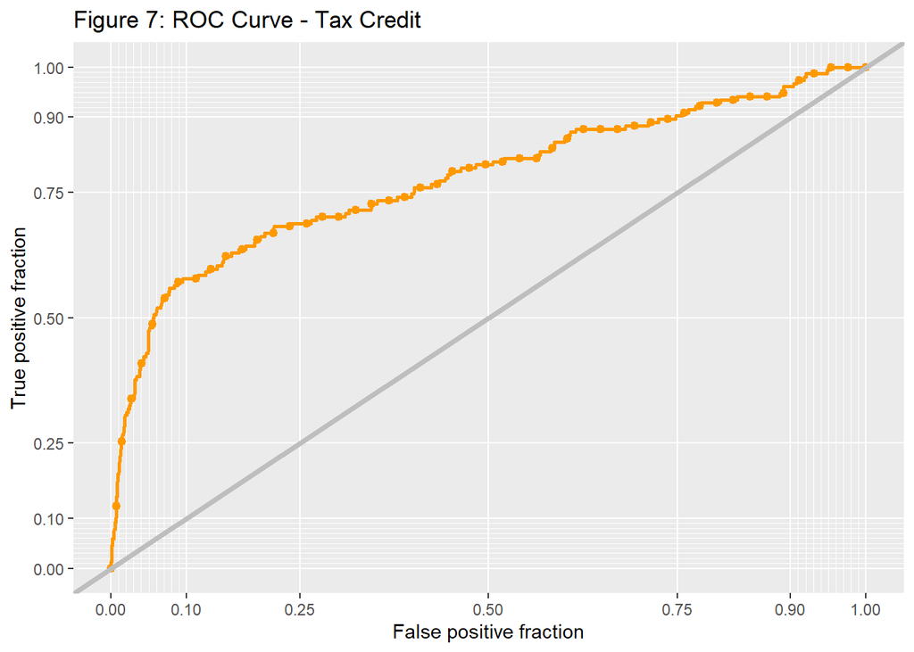

```r
ggplot(testProbs, aes(d = as.numeric(testProbs$Outcome), m = Probs)) +
  geom_roc(n.cuts = 50, labels = FALSE, colour = "#FE9900") +
  style_roc(theme = theme_grey) +
  geom_abline(slope = 1, intercept = 0, size = 1.5, color = 'grey') +
  labs(title = "Figure 7: ROC Curve - Tax Credit")
```

```r
pROC::auc(testProbs$Outcome, testProbs$Probs)
```

```
## Area under the curve: 0.7764
```

### 3.8 Cost/Benefit analysis

In the final, our aim is to create a cost-benefit analysis, in order to optimize the resource distribution and move toward a more targeted campaign.

We have the following assumptions about the marketing campaign:

- Marketing Resources Cost: $2,850
- Credit Cost: $5,000
- Houses that transacted after taking the credit, sold with a $10,000 premium, on average.
- Homes surrounding the repaired home see an aggregate premium of $56,000, on average.

Through these assumptions, below the cost/benefit for each outcome in our confusion matrix is calculated:

**True Negative Revenue**: Predicted correctly homeowner would not take the credit, no marketing resources were allocated, and no credit was allocated. Count * 0.

**True Positive Revenue**: Predicted correctly homeowner would enter credit program; allocated the marketing resources, and 25% ultimately achieved the credit:

- Marketing Cost: -$2,850 * Count;
- Credit Cost: -$5,000 * Count * 0.25;
- Houses Premium: +$10,000 * Count * 0.25;
- Neighborhood Premium: +$56,000 * Count * 0.25.

**False Negative Revenue**: We predicted that a homeowner would not take the credit but they did. These are likely homeowners who signed up for reasons unrelated to the marketing campaign. Thus, we ‘0 out’ this category, assuming the cost/benefit of this is $0.

**False Positive Revenue**: Predicted incorrectly homeowner would take the credit; allocated marketing resources; no credit allocated.

- Marketing Cost: -$2,850 * Count;

In our analysis, the revenue is 0$ in true_negative and false_negative, which means the department doesn’t lose money. As the threshold value increases, false_positive revenue gradually rises and true_positive falls, eventually converging to 0.

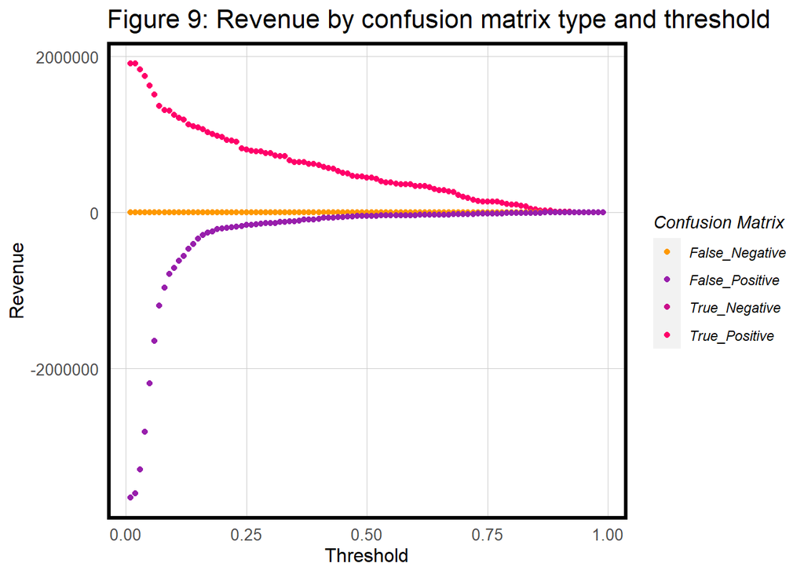

```r
iterateThresholds <- function(data) {
  x = .01
  all_prediction <- data.frame()
  while (x <= 1) {

  this_prediction <-
      testProbs %>%
      mutate(predOutcome = ifelse(Probs > x, 1, 0)) %>%
      count(predOutcome, Outcome) %>%
      summarize(True_Negative = sum(n[predOutcome==0 & Outcome==0]),
                True_Positive = sum(n[predOutcome==1 & Outcome==1]),
                False_Negative = sum(n[predOutcome==0 & Outcome==1]),
                False_Positive = sum(n[predOutcome==1 & Outcome==0])) %>%
     gather(Variable, Count) %>%
     mutate(Revenue =
               ifelse(Variable == "True_Negative", (Count * 0),
               ifelse(Variable == "True_Positive", (Count * (-2850) + (-5000) * (Count * .25) + (Count * .25) * 10000 + (Count * .25) * 56000),
               ifelse(Variable == "False_Negative", (Count * 0),
               ifelse(Variable == "False_Positive", (Count * -2850), 0)
               )
               )
               ),
            Threshold = x)
  all_prediction <- rbind(all_prediction, this_prediction)
  x <- x + .01
  }
return(all_prediction)
}

whichThreshold <- iterateThresholds(testProbs)

whichThreshold_revenue <-
  whichThreshold %>%
  group_by(Threshold) %>%
  summarize(Revenue = sum(Revenue))

whichThreshold %>%
  ggplot(.,aes(Threshold, Revenue, colour = Variable)) +
  geom_point() +
  scale_colour_manual(values = palette5[c(5, 1:3)]) +
  labs(title = "Figure 9: Revenue by confusion matrix type and threshold",
       y = "Revenue") +
  plotTheme() +
  guides(colour=guide_legend(title = "Confusion Matrix"))
```

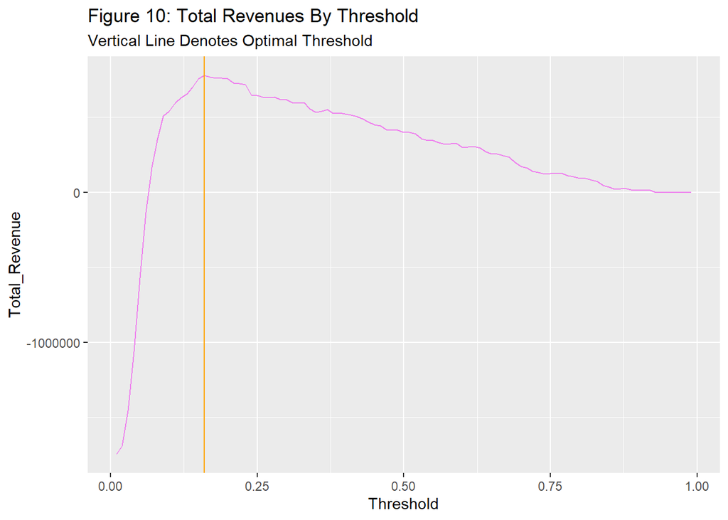

```r
whichThreshold_revenue <-
  whichThreshold %>%
    mutate(TookCredit = ifelse(Variable == "True_Positive", (Count * .25),
                         ifelse(Variable == "False_Negative", Count, 0))) %>%
  group_by(Threshold) %>%
  summarize(Total_Revenue = sum(Revenue),
            Total_Count_Of_Credits = sum(TookCredit))

# Total Revenues
ggplot() +
  geom_line(data = whichThreshold_revenue, aes(x = Threshold, y = Total_Revenue), colour = "violet") +
  geom_vline(xintercept =  pull(arrange(whichThreshold_revenue, -Total_Revenue)[1,1]), colour = "Orange")+
    labs(title = "Figure 10: Total Revenues By Threshold",
         subtitle = "Vertical Line Denotes Optimal Threshold")
```

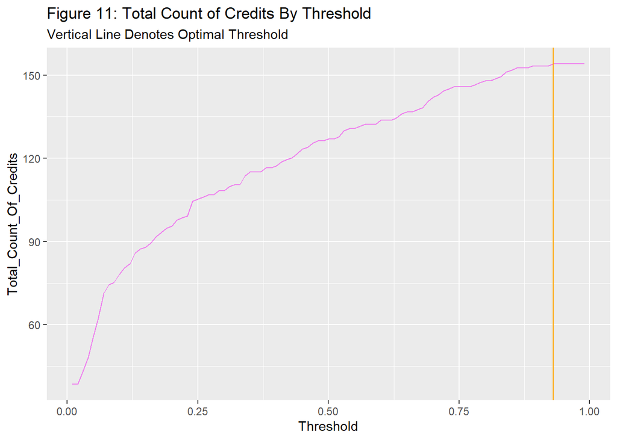

```r
# Credits
ggplot(whichThreshold_revenue)+
  geom_line(aes(x = Threshold, y = Total_Count_Of_Credits), colour = "violet")+
  geom_vline(xintercept =  pull(arrange(whichThreshold_revenue, -Total_Count_Of_Credits)[1,1]), colour = "Orange")+
    labs(title = "Figure 11: Total Count of Credits By Threshold",
         subtitle = "Vertical Line Denotes Optimal Threshold")
```

```r
optimalthreshold <-
  whichThreshold_revenue %>%
  dplyr::select(Threshold, Total_Revenue, Total_Count_Of_Credits)

optimalthreshold_table <-
  optimalthreshold %>%
  filter(Threshold == "0.18" | Threshold == "0.5" )

kable(optimalthreshold_table,
       caption = "Cost/Benefit Table") %>% kable_styling()
```

Cost/Benefit Table

| Threshold | Total_Revenue | Total_Count_Of_Credits |
| --- | --- | --- |
| 0.18 | 762150 | 93.25 |
| 0.50 | 400800 | 127.00 |